# Analysis of my reading journey

Phan Nguyen

12/24/2020

# Introduction

Hello everyone, welcome to an Analysis of my reading journey. A little bit of background: I started reading again in 2018, after a long time of not touching books. The last book I had read before was when I was in 8th grade :D.

Since I started reading in 2018, I’ve been keeping track of the books I read, rating and reviews on Goodreads, and after two years, I had this small set of data available.I came across it the other day, when Goodreads showed me some stats on their website.

Moreover, I recently started learning data science on my own, therefore I am so thrilled to analyze this data. My purpose of this analysis is to answer some few questions: 1. How much books I’ve read over the years? 2. Are there correlation between time of year and the amount of reading ? 3. Do I give better rating than other people do? 4. What is my favourite genre?

I am new to this, so if you have any comments or suggestions, please let me know!

LET’S DIVE IN!

## The Goodreads Data

First, let grab our data

```r
data <- read.csv("C:\\Users\\nguyen_phan\\Downloads\\goodreads_library_export.csv",encoding="UTF-8",header=TRUE,stringsAsFactors = FALSE)
```

```r
dim(data)
```

```
## [1] 57 31
```

There are 57 books in this data. This include books I read, currently am reading, and going to read. This is a small data set, however I believe there are some interesting insights in this one. Each of this book has 31 variables to describe it.

This is a sample of the data set. We have name of book, author, my rating, other people’ rating, number of pages, date read, date added.

| Title | Author | My.Rating | Average.Rating | Binding | Number.of.Pages | Date.Read | Date.Added | Exclusive.Shelf |
| --- | --- | --- | --- | --- | --- | --- | --- | --- |
| Before the Fall | Noah Hawley | 5 | 3.72 | Paperback | 416 | 2020/01/25 | 2020/01/25 | read |
| Financial Freedom: A Proven Path to All the Money You Will Ever Need | Grant Sabatier | 5 | 4.00 | Hardcover | 352 | 2020/08/02 | 2020/06/18 | read |
| The Start-up of You: Adapt to the Future, Invest in Yourself, and Transform Your Career | Reid Hoffman | 4 | 3.85 | Hardcover | 260 | 2020/12/11 | 2020/11/27 | read |
| The Comprehensive INFP Survival Guide | Heidi Priebe | 4 | 4.24 | Paperback | 274 | 2020/04/20 | 2020/04/14 | read |
| The Subtle Art of Not Giving a F*ck: A Counterintuitive Approach to Living a Good Life | Mark Manson | 5 | 3.94 | Paperback | 206 | 2020/03/05 | 2020/03/01 | read |

First, I will convert some variables to its proper data type.

## Books

```r
shelf1 <- as.data.frame(table(data$Exclusive.Shelf))
colnames(shelf1)[1] <- "Shelf"
kable(shelf1)
```

| Shelf | Freq |
| --- | --- |
| currently-reading | 1 |
| read | 51 |
| to-read | 5 |

I have read 51 books so far.

We are only interested in looking at books I have read, therefore we will filter read books.

And also make make some variables less mouthful.

```r
# filter read books
rdata<-data %>% filter(Exclusive.Shelf=='read')
#easier to see
rdata <- as_tibble(rdata)

#make this variable sh
names(rdata)[names(data)=='Original.Publication.Year'] <- "opy"
```

I am interested in seeing read books by year

```r
# create shelf 2, dataframe split books read by year
shelf2 <- rdata %>% group_by(year(Date.Read)) %>% select('year(Date.Read)')
shelf2 <- as.data.frame(table(shelf2[,1]))
shelf2 <- mutate(shelf2,pct_change=round((Freq/lag(Freq)-1)*100,2))
colnames(shelf2) <- c("Year","Books Read","Percent Change")
```

```r
#create a table
kable(shelf2)
```

| Year | Books Read | Percent Change |
| --- | --- | --- |
| 2018 | 9 | NA |
| 2019 | 19 | 111.11 |
| 2020 | 23 | 21.05 |

There was a big jump between 2018 and 2019 in terms of book read (111%). However, there was no significant change from 2019 to 2020 (21%). I’m reading more books each year, but at a decreasing rate.

Here are the oldest and newest books

```r
#create a table with row as the title of the newest books, remove missing values
table <- tibble(rdata$Title[rdata$opy==max(na.omit(rdata$opy))&is.na(rdata$opy)==FALSE])
table[,2] <- rep(max(na.omit(rdata$opy),nrow(table)))
colnames(table) <- c("Newest books","Year")
kable(table)

#create a table with row as the title of the oldest books, remove missing values
table <- tibble(rdata$Title[rdata$opy==min(na.omit(rdata$opy))&is.na(rdata$opy)==FALSE])
table [,2] <- rep(min(na.omit(rdata$opy)),nrow(table))
colnames(table) <- c("Oldest books","Year")
kable(table)
```

| Newest books | Year |
| --- | --- |
| Bạn Có Phải Là Đứa Trẻ Sợ Hãi Ẩn Sau Lớp Vỏ Trưởng Thành? | 2018 |
| Educated | 2018 |

| Oldest books | Year |
| --- | --- |
| The Richest Man in Babylon | 1926 |

Here are the thickest book and the least thickest book

```r
table1 <- tibble(rdata$Title[which.max(rdata$Number.of.Pages)])
max(rdata$Number.of.Pages,na.rm = TRUE)
```

```
## [1] 660
```

```r
rdata$Title[which.min(rdata$Number.of.Pages)]
```

```
## [1] "Nhân Tố Enzyme: Minh Họa"
```

```r
min(rdata$Number.of.Pages,na.rm=TRUE)
```

```
## [1] 79
```

## Speed

Another information I want to know is how fast do I finish a book? I will create a variable in rdata, to calculate the speed. Speed will equal to Number of pages divided by Days Difference or **datediff**.

**datediff** is calculated by taking Date Read minus Date Added

```r
# days to finish a book
rdata$datediff <- difftime(rdata$Date.Read,rdata$Date.Added,units = "day")
rdata$datediff
```

```
## Time differences in days
##  [1]    0   45   14    6    4    1   12   53    9   34  157   12  -15 -143    0
## [16]   -4    0    0    0    0   20   54   21   16   13    0    5    4  620    0
## [31]   37    0    1   30   14    0    0   42    8   26   28    0    9   13    0
## [46]  228 -156    6  185    3   12
```

The disadvantage of Goodreads export data is that it only allows **Date Added** and **Date Read**. **Date Added** is when I added the book to my shelf, and Date Read is when I claimed to finish it. Normally, **Date Read** will be after **Date Added**, if I added on the day I started reading it, which results in a positive **datediff**.

There are instances where I updated a book after I finished it, therefore **Date Read** will be before **Date Added**. The negative represents those cases.

The 0s are the cases where I added the book right on the day I finished it.

There is another column called Date Started on Goodreads, but they don’t allow you to export it.

```r
#count datediff which smaller than 1
aggregate(rdata$datediff,list(rdata$datediff<1), FUN=length)
```

```
##   Group.1  x
## 1   FALSE 34
## 2    TRUE 17
```

I will remove the 0 and the negative to calculate speed. 17 books will be removed

```r
rdata$speed  <- rdata$Number.of.Pages/as.integer(rdata$datediff)
speedat <- rdata%>% filter(speed>0&is.na(rdata$speed)==FALSE&speed!=Inf)
speedat$speed
```

```
##  [1]   7.8222222  18.5714286  45.6666667  51.5000000 191.0000000  36.8333333
##  [7]   9.3207547  58.2222222  11.2352941   2.1210191  24.3333333  12.7500000
## [13]   4.9629630   9.9047619  20.8750000  24.1538462  57.8000000  84.5000000
## [19]   0.7161290   8.2162162 102.0000000  17.7333333  25.0000000  15.7142857
## [25]  21.8750000   8.5769231  10.7142857  29.1111111  46.7692308   0.5175439
## [31]  56.0000000   3.3675676  97.3333333  17.3333333
```

```r
mean(speedat$speed)
```

```
## [1] 33.31033
```

My average reading speed is 33.31 pages/day

Let’s look at it through year

```r
speedat %>% group_by(year(Date.Read))%>%summarise(avgspeed = mean(speed,na.rm=TRUE))
```

```
## # A tibble: 3 x 2
##   `year(Date.Read)` avgspeed
##               <dbl>    <dbl>
## 1              2018     41.7
## 2              2019     40.1
## 3              2020     26.7
```

Average speed in 2018 somehow is the highest, despite the low number of books. Is it because of the number of pages per book?

```r
kable(speedat %>% group_by(year(Date.Read))%>%summarise(avgspeed = mean(speed,na.rm=TRUE),avgpages = mean(Number.of.Pages,na.rm=TRUE),n=n()) %>% mutate(truen=shelf2$`Books Read`) %>% mutate(removed=truen-n))
```

| year(Date.Read) | avgspeed | avgpages | n | truen | removed |
| --- | --- | --- | --- | --- | --- |
| 2018 | 41.65243 | 388.1667 | 6 | 9 | 3 |
| 2019 | 40.13476 | 295.5000 | 10 | 19 | 9 |
| 2020 | 26.73828 | 333.8333 | 18 | 23 | 5 |

The average number of pages in 2018 is actually higher than 2019 and 2020. From what I understand, I read less books in 2018, but in a short window. In 2020, I read more books, more frequently, but at slower pace.

The removed data also play a part here. There are 3 books removed for 2018, 9 for 2019 and 5 for 2020. Even though 2020 has double the books of 2018, it might be that the books which are removed in 2020 have a really high number of pages.

Or I just read super fast in a short window in 2018.

## Number of Pages

We will look at number of pages I’ve read. Books have different number of pages.

[figure not shown]

```r
datagraph <- data %>% mutate(month=floor_date(Date.Read,unit="month")) %>% group_by(month) %>% mutate(sumpages=sum(Number.of.Pages,na.rm = TRUE))
```

As you can see, I’m not a consistent reader :D.

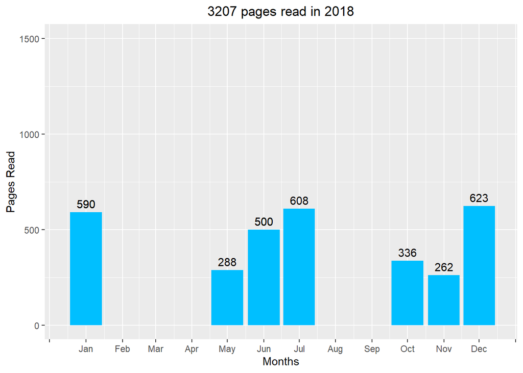

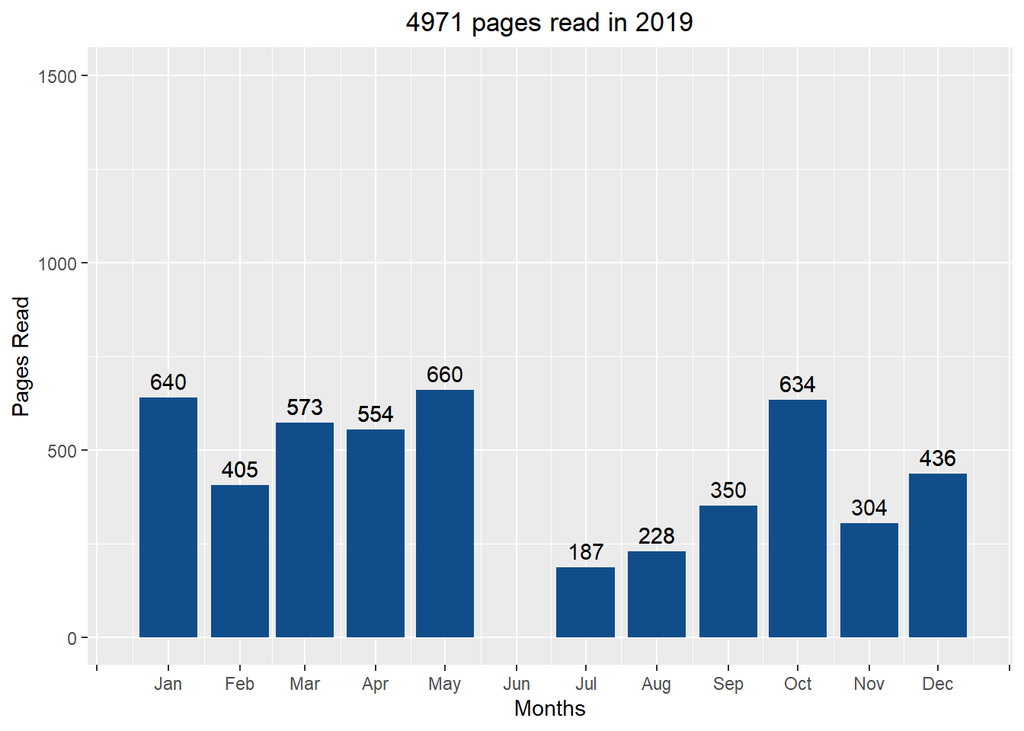

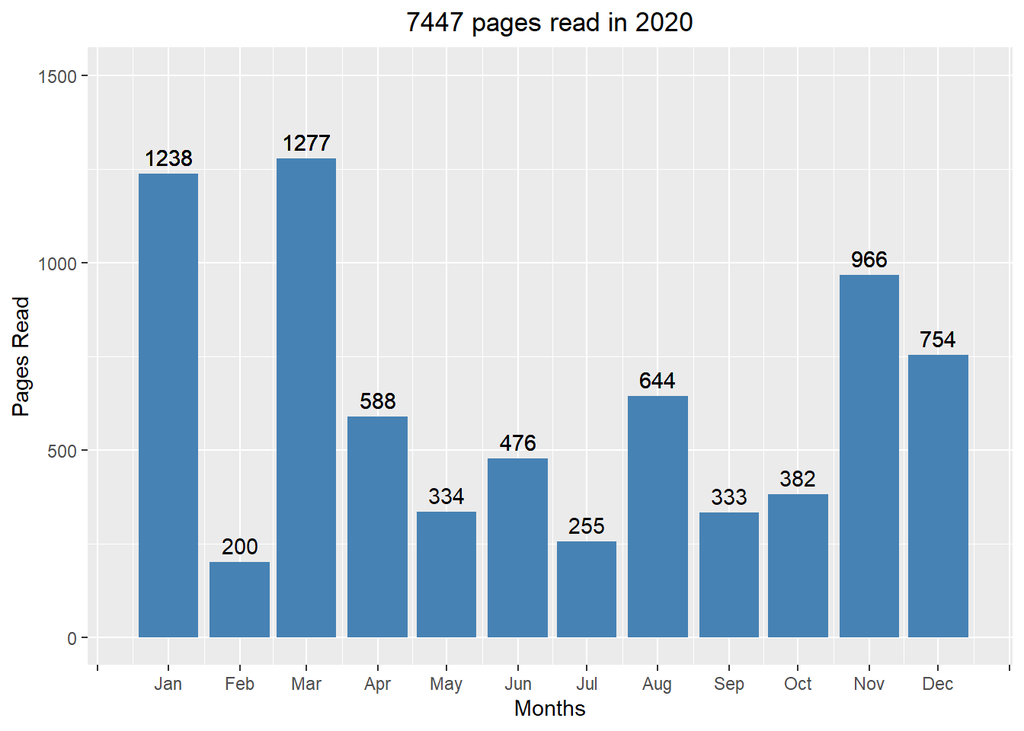

## Rating

I want to compare my ratings with average book rating

```r
#My rating vs average rating
mean(data$My.Rating)
```

```
## [1] 3.912281
```

```r
mean(data$Average.Rating)
```

```
## [1] 4.084035
```

```r
#creating a dataset of my rating versus average rating
ratedata<-aggregate(rdata$Average.Rating,list(myrating=rdata$My.Rating),FUN="mean")
ratedata$class <- ratedata$myrating
for (i in c(0:nrow(ratedata))){ratedata[i,3]<- ratedata$myrating[i]}
colnames(ratedata)[2] <-"avg"
ratedata <- gather(ratedata,var,value,myrating,avg)
```

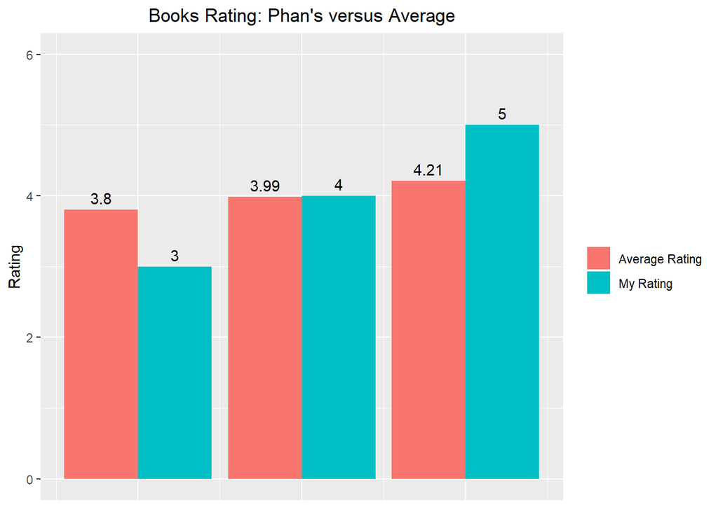

```r
#plot it
ggplot(ratedata, aes(x=class,y=value,fill=var))+
  geom_bar(stat='identity',position='dodge')+
  geom_text(aes(label=round(value,2)),vjust=-.5,position=position_dodge(width=0.9))+
  labs(y="Rating",title="Books Rating: Phan's versus Average")+
  ylim(0,6)+
  theme(plot.title = element_text(hjust = 0.5),legend.title=element_blank(),axis.title.x = element_blank(),axis.text.x = element_blank(),axis.ticks.x = element_blank()) +
  scale_fill_discrete(labels = c("Average Rating", "My Rating"))
```